# PAC2: Anàlisi de dades d’ultrasecuenciació, RNA-seq amb Bioconductor

Magda Pla Montferrer

11 junio, 2020

El present informe i les seves dades es pot consultar a https://github.com/MagdaPla/ADO_PAC2.git

# 1. Abstract

En aquest document es proposa una metodologia amb el codi en R complet per a realitzar un procés d’anàlisis de dades d’ultraseqüenciació (RNA-seq) amb Bioconductor proposant un flux d’informació basat en els estàndars proposats a la web de Bioconductor (http://master.bioconductor.org/packages/release/workflows/vignettes/rnaseqGene/inst/doc/rnaseqGene.html#aligning-reads-to-a-reference-genome).

# 2. Objectius

L’objectiu principal del document és il·lustrar un procés d’anàlisis de dades d’ultraseqüenciació mitjançant la realització d’un estudi de principi a fi com es pot dur a terme en un cas real.

# 3. Material i mètodes

## 3.1.Naturalesa de les dades

En aquesta proposta metodològica es parteixen de dades extretes del repositori GTEx ( *Genotype-Tissue Expression*) que conté múltiple informació de 54 tipus de teixits. Concretament ens centrarem en les dades d’expressió (RNA-seq) d’un anàlisis de tiroides on es comparen tres tipus d’infiltracions mesurades en un total de 292 mostres:

• *Not infiltrated tissues* (NIT): 236 mostres

• *Small focal infiltrates* (SFI): 42 mostres

• *Extensive lymphoid infiltrates* (ELI): 14 mostres.

Sobre aquest nombre de mostres es seleccionaran a l’atzar 10 mostres de cada grup i s’analitzaran les dades d’expressió comparant diferents grups entre ells.

## 3.2 Mètodes utilitzats en l’anàlisis

Per a començar haurà estat necessari preparar els directoris corresponents on emmagatzemar les dades brutes i si convé els directoris on es desaran els resultats. També s’haurà realitzarà la instal·lació de les llibreries necessàries. Una vegada la part més tècnica estigui a punt, es procedeix a realitzar l’anàlisis: preparació de les dades i anàlisis d’ultraseqüenciació pel que es proposen els següents passos:

*1. Definició de les dades utilitzades (realitzat en el punt 3.1)

*2. Selecció de les mostres a l’atzar

*3. Processat de les dades: filtrat i normalització

*4. Identificació de gens diferencialment expresats

*5. Anotació dels resultats

*6. Cerca de patrons d’expressió i agrupació de les mostres (comparació entre les diferents comparacions)

*7. Anàlisis de significació biològica (“Gene Enrichment Analysis”)

## 3.3.Procediment

### 3.3.1. Selecció de les mostres a l’atzar.

La informació de partida es troba en dos fitxers: counts.csv i targets.csv; els quins es desaran en el directori “dades”. El fitxer `targets.csv` conté una descripció de cadascuna de les 292 mostres originals (grup, gènere, mostra, etc.). El fitxer `counts.csv` conté pròpiament la informació del RNA-m la ultraseqüenciació, té tantes columnes com mostres i en cada registre hi ha la inforemació d’expressió gènica d’interès. Les taules següents són una petita mostra del contingut dels fitxers.

Taula 1. Contingut del fitxer *targets.csv* utilitzat en aquest anàlisis

|  | SRA_Sample | Sample_Name | Grupo_analisis | body_site | molecular_data_type | sex | Group | ShortName |
| --- | --- | --- | --- | --- | --- | --- | --- | --- |
| SRX567480 | SRS626942 | GTEX-111CU-0226-SM-5GZXC | 1 | Thyroid | Allele-Specific Expression | male | NIT | 111CU_NIT |
| SRX615964 | SRS644174 | GTEX-111FC-1026-SM-5GZX1 | 1 | Thyroid | RNA Seq (NGS) | male | NIT | 111FC_NIT |
| SRX563960 | SRS625636 | GTEX-111VG-0526-SM-5N9BW | 3 | Thyroid | RNA Seq (NGS) | male | ELI | 111VG_ELI |
| SRX564185 | SRS625665 | GTEX-111YS-0726-SM-5GZY8 | 1 | Thyroid | Allele-Specific Expression | male | NIT | 111YS_NIT |
| SRX559141 | SRS624025 | GTEX-1122O-0226-SM-5N9DA | 1 | Thyroid | RNA Seq (NGS) | female | NIT | 1122O_NIT |
| SRX561718 | SRS625313 | GTEX-1128S-0126-SM-5H12S | 1 | Thyroid | Allele-Specific Expression | female | NIT | 1128S_NIT |

Taula 2. Mostra del contingut del fitxer *counts.csv* utilitzat en aquest anàlisis, concretament els 5 primers registres i les tres primeres columnes

|  | GTEX.111CU.0226.SM.5GZXC | GTEX.111FC.1026.SM.5GZX1 | GTEX.111VG.0526.SM.5N9BW |
| --- | --- | --- | --- |
| ENSG00000223972.4 | 7 | 0 | 1 |
| ENSG00000227232.4 | 401 | 1064 | 474 |
| ENSG00000243485.2 | 4 | 0 | 1 |
| ENSG00000237613.2 | 2 | 0 | 0 |
| ENSG00000268020.2 | 0 | 0 | 1 |

El camp “Group” de la taula `targets.csv` indica el tipus d’infiltració: NIT, SFI o ELI. El camp “Sample_Name” conté el nom de la mostra que es correspon amb cadascuna de les columnes de el fitxer `counts.csv`. Així doncs, a sobre el fitxer `targets.csv` es sel·leccionaran 10 mostres a l’atzar de cada grupa partir del camp “Group”. A partir del camp “Sample_Name” de la sel·lecció feta s’extrauran les columnes corresponents del fitxer `counts.csv.

NOTA: en aquest exemple concret, hi ha dades mol·leculars tipus RNA-seq i també Expressió al·lèlica específica. Es pren la decisió de sel·leccionar només els registres amb informació només de RNA-seq.

Per a fer la sel·lecció a l’atzar s’ha utilitzat la llibreria **dplyr**, la funció `filter()` primer per a filtrar els registres de dades de RNA-seq i a continuació les funcions de `sample_n()` i `by_group()` per a escollir a l’atzar n mostres de cada grup.

```r
> library(dplyr) # realitzem la sel·lecció amb la llibreria 'dplyr'
> RNAseq_targets <- filter(targets, molecular_data_type=="RNA Seq (NGS)")
>
>
> set.seed(123) # per a fer la sel·lecció reproduïble definim una llavor
> # primer de tot es fa una agrupació de la taula target per el camp "Group"
> agrupa <- RNAseq_targets %>% group_by(Group)
>
> # A continaució amb 'sample_n()' sel·leccionem de cada grup 10 mostres a l'atzar de cada grup.
> sel<-sample_n(agrupa, 8)
```

NOTA: en aquest cas concret de dades, resulta que d’una de les categories de infiltració amb dades de RNA-seq només hi ha 8 mostres. Es podria escollir una opció que permetés repetir mostres o bé permetre que d’un grup hi hagi menys mostres, però s’ha cregut convenient disminuïr el nombre de mostres de cada grup per tal de no esbiaixar els resultats.

Les mostres sel·leccionades són les següents:

[output not shown]

Per a poder fer la extracció de les columnes corresponents a la taula `counts.csv` em cal canviar una mica la nomenclatura del nom dels fitxers. Concretament, cal substituïr el caràcter “-” per “.”. Hi ha moltes maneres de fer-ho, la proposada crea un nou camp amb la nomenclatura correcte utilitzant la funció `g_sub()`:

```r
> #definim la selecció com un data.frame
> sel1<-as.data.frame(sel)
> # canviem el caràcter desitjat creant un nou camp i alhora es crea un vector amb tots els noms sel·leccionats
> New_Sample_Name<-gsub("-", ".", sel1$Sample_Name)
> # unim el nou camp a la taula final per si ho necessitem més endavant
> target_subset<-cbind(sel1,New_Sample_Name)
> # veiem una petita mostra
> # head(target_subset)
```

A continuació cal extreure la informació del fitxer `counts.csv` només per a les mostres seleccionades a l’atzar en aquest primer pas. Es pot utilitzar també amb el paquet **diplyr** i la funció `select()`:

```r
> #utilitzem el vector "New_sample_Name" per seleccionar els camps requerits i també el primer camp "X"
> counts_subset <- select(counts,all_of(c(target_subset$New_Sample_Name)))
> # altres comprobacions de la extracció
> dim(counts_subset)
```

```
[1] 56202    24
```

```r
> #names(counts_subset)
> #head(counts_subset[1:3, 1:3])
```

```r
> library(DESeq2)
> library(Rsubread)
>
> countdata<-counts_subset
> coldata<- target_subset
>
> ddsMat <- DESeqDataSetFromMatrix(countData = countdata,
+                                  colData = coldata,
+                                  design = ~ Group)
>
> ddsMat
```

```
class: DESeqDataSet
dim: 56202 24
metadata(1): version
assays(1): counts
rownames(56202): ENSG00000223972.4 ENSG00000227232.4 ...
  ENSG00000210195.2 ENSG00000210196.2
rowData names(0):
colnames(24): GTEX.11DZ1.2726.SM.5A5KH GTEX.11EQ8.0826.SM.5N9FG ...
  GTEX.111VG.0526.SM.5N9BW GTEX.1192X.1126.SM.5EGGU
colData names(9): SRA_Sample Sample_Name ... ShortName New_Sample_Name
```

### 3.3.3 Processat de les dades: filtrat i normalització

Hi ha algunes contatges que tenen valors més baixos. Pot resultar recomanable filtrar aquestes registres de cara a no esbiaixar els resultats. En aquest exercici es realitzarà un filtrat dels registres que tenen 0 contatges en tots els experiments o bé els que tenen contatges en un sol experiment.

```r
> keep <- rowSums(DESeq2::counts(ddsMat)) > 1
> ddsMat <- ddsMat[keep,]
```

Després d’aquest filtrat, la mida de la matriu de contatges es redueix passant de *56202* registres a *41464*.

També es realitzarà un procés de normalització o estabilització de la variança. S’utilitzarà el mètode VST implementat a *DESeq2*, perquè és ràpid i recomanable per datasets mitjans. En la funció `vst()` li indiquem el paràmetre “blind=FALSE” la diferència entre les variables en el disseny (el tipus d’infiltració) no s’utilitzi en la transforamció, només en estimar la quantaitat de variació total en els contatges.

```r
> vsd <- vst(ddsMat, blind = FALSE)
```

Tal i com es pot veure a continaució, el mètode VST retorna un objecte DESeqTransform basat en la classe SummarizedExperiemnt així que per a veure-ho cal utilitzar la funció `assay()` doncs emmagatzema la informació en un “assay” i podem visualitzar-los fent un `assay(vsd)`. Tal i com es mostra a la taula següent, els valors transformats ja no són contatges:

Taula 4. Transformació dels contatges amb el mètode VST

|  | GTEX.11DZ1.2726.SM.5A5KH | GTEX.11EQ8.0826.SM.5N9FG | GTEX.1128S.0126.SM.5H12S | GTEX.11DYG.0826.SM.5N9GH | GTEX.111YS.0726.SM.5GZY8 | GTEX.11DXX.0226.SM.5P9HL | GTEX.11DXY.0426.SM.5H12R | GTEX.111CU.0226.SM.5GZXC | GTEX.11EQ9.0626.SM.5A5K1 | GTEX.11GSO.0626.SM.5A5LW | GTEX.1122O.0226.SM.5N9DA | GTEX.1192W.0126.SM.5EGGS | GTEX.11EI6.0726.SM.59866 | GTEX.11EM3.0126.SM.5985K | GTEX.11DXZ.0926.SM.5N9CG | GTEX.11GS4.0826.SM.5986J | GTEX.117YW.0126.SM.5EGGN | GTEX.111FC.1026.SM.5GZX1 | GTEX.117XS.0526.SM.5987Q | GTEX.113JC.0126.SM.5EGJW | GTEX.117YX.1226.SM.5H11S | GTEX.11EMC.0226.SM.5EGLP | GTEX.111VG.0526.SM.5N9BW | GTEX.1192X.1126.SM.5EGGU |
| --- | --- | --- | --- | --- | --- | --- | --- | --- | --- | --- | --- | --- | --- | --- | --- | --- | --- | --- | --- | --- | --- | --- | --- | --- |
| ENSG00000223972.4 | 3.913035 | 4.263879 | 4.453268 | 4.540898 | 4.683517 | 4.522298 | 3.913035 | 4.824757 | 4.699176 | 3.913035 | 4.459962 | 4.576688 | 4.268256 | 4.408422 | 4.302787 | 3.913035 | 4.345547 | 3.913035 | 4.618512 | 3.913035 | 4.557228 | 4.650626 | 4.292121 | 4.476263 |
| ENSG00000227232.4 | 9.270498 | 9.546587 | 9.459554 | 9.494042 | 8.858295 | 9.209793 | 9.385220 | 8.591715 | 9.018834 | 9.292266 | 9.700037 | 9.343045 | 9.223792 | 9.298644 | 9.780348 | 9.177395 | 9.427624 | 9.917796 | 9.356819 | 8.737639 | 9.150257 | 9.371483 | 9.037655 | 9.667925 |
| ENSG00000243485.2 | 3.913035 | 4.263879 | 3.913035 | 3.913035 | 4.461045 | 4.219359 | 3.913035 | 4.607047 | 4.557515 | 3.913035 | 4.300921 | 4.298435 | 4.414141 | 4.408422 | 3.913035 | 4.289302 | 3.913035 | 3.913035 | 4.323031 | 4.318918 | 3.913035 | 3.913035 | 4.292121 | 4.600706 |

### 3.3.4 Identificació de gens diferencialment expresats

Un dels primera passos per analitzar les diferències i similituds entre mostres, claculant la istància entre aquestes i visualitzant les distàncies amb gràfiques.

```r
> sampleDists <- dist(t(assay(vsd)))
> #sampleDists
```

Es podria consultar la taula resultant de distàncies però pot resultar més entenedor veure les distàncies entre mostres de manera gràfica. Es poden representar les dades utilitzant mapes de calor (heat maps), les components principals (PCA) o també el *Multidimensional Scalling* o MDS. A continuació s’ha preparat el codi per els tres tipus de gràfics, però després d’analitzar les dades concretes de l’exemple només es mostra el resultat de les PCA, la resta de codi es descriu per a poder repetir l’exercici amb altres dades.

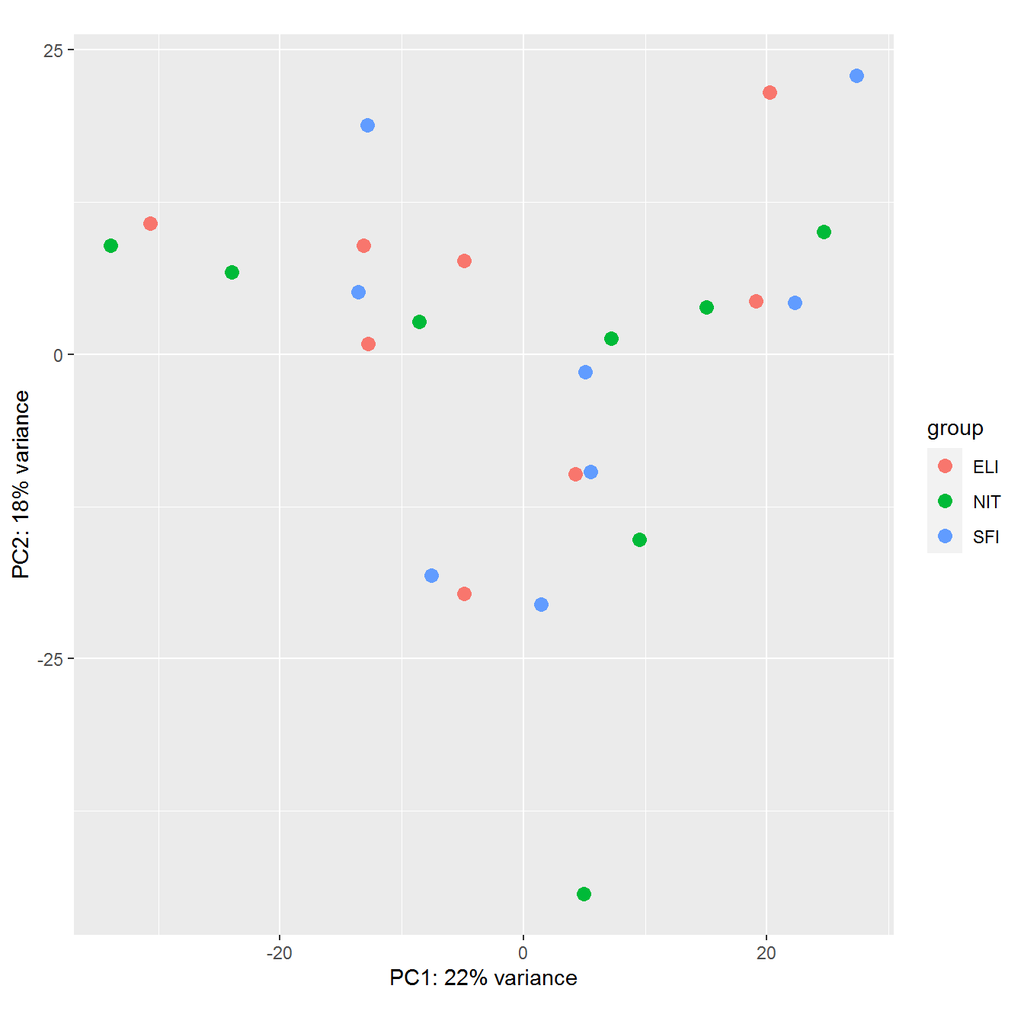

```r
> # Mapa de calor o HeatMap:
> library(pheatmap)
> library(RColorBrewer)
>
> #sampleDistMatrix <- as.matrix( sampleDists )
> #rownames(sampleDistMatrix) <- vsd$Group
> #colnames(sampleDistMatrix) <- NULL
> #colors <- colorRampPalette( rev(brewer.pal(9, "Blues")) )(255)
> #pheatmap(sampleDistMatrix,
> #         clustering_distance_rows = sampleDists,
> #         clustering_distance_cols = sampleDists,
> #         col = colors)
>
>
> # PCA
> plotPCA(vsd, intgroup = c("Group"))
```

```r
> #library(ggplot2)
> #mds <- as.data.frame(colData(vsd))  %>%
> #         cbind(cmdscale(sampleDistMatrix))
> #ggplot(mds, aes(x = `1`, y = `2`, color = vsd$Group)) +
> #  geom_point(size = 3) + coord_fixed()
```

El gràfic de les dues compoents principals no és massa explicatiu per aquestes dades. La primera i segona component expliquen només el 22% i 18% respectivament (menys del 50% entre les dues) i alhora les mostres no semblen tanir cap patró en funció del grup d’infiltració. No obstant, en el context de l’exercici s’ha cregut important mostrar la possibilitat de mostrar una representació gràfica de les dades i obrir la possibilitat a realitzar altres tipus de representació.

A continuació es procedeix pròpiament amb l’anàlisis de l’expressió diferencial, es pot utilitzar la funció DESeq sobre la matriu de contatges. S’ha utilitzat la funció `DESeq()`del paquet **DESeq2**, però també es podrin utilitzar altres paquets com **edgeR** (https://www.bioconductor.org/packages/release/bioc/html/edgeR.html).

```r
> dds <- DESeq(ddsMat, parallel =TRUE)
```

Tal i com es pot veure per un fragment de la informació contrastada:

```r
> res<-results(dds)
> res
```

```
log2 fold change (MLE): Group SFI vs ELI
Wald test p-value: Group SFI vs ELI
DataFrame with 41464 rows and 6 columns
                           baseMean      log2FoldChange             lfcSE
                          <numeric>           <numeric>         <numeric>
ENSG00000223972.4  2.02506644081728  -0.316666123265171 0.785759071240452
ENSG00000227232.4  617.001783316758   0.120819886022213 0.177936363305724
ENSG00000243485.2  1.00761870435333  -0.129011076413899   1.1101359240938
ENSG00000237613.2 0.904538323997087   0.848232687805492  1.23154381070268
ENSG00000268020.2 0.236784379495776   0.588262139085438  2.14265312142749
...                             ...                 ...               ...
ENSG00000198695.2  59095.5534213059   -1.10791472970419  0.81695747671296
ENSG00000210194.1  24.4993641537878   -1.97359024337784 0.885701561808004
ENSG00000198727.2  429482.661599931 -0.0557436548764488 0.412148110578169
ENSG00000210195.2 0.404503088047115   0.592805389753947  1.63791636299248
ENSG00000210196.2  1.97285130602105    1.15383983761251  1.06415996129826
                                stat             pvalue              padj
                           <numeric>          <numeric>         <numeric>
ENSG00000223972.4 -0.403006640146401  0.686943339649919                NA
ENSG00000227232.4   0.67900615578292  0.497133961553261 0.864034159623817
ENSG00000243485.2 -0.116211964331494  0.907484554835899                NA
ENSG00000237613.2    0.6887555931295  0.490977085041046                NA
ENSG00000268020.2  0.274548471333299  0.783663159298145                NA
...                              ...                ...               ...
ENSG00000198695.2  -1.35614736541968  0.175052285006739 0.658906015613738
ENSG00000210194.1   -2.2282790597649 0.0258619118360049 0.387000968934251
ENSG00000198727.2 -0.135251511400236  0.892413021009287 0.978728580029889
ENSG00000210195.2  0.361926532482335  0.717406932086398                NA
ENSG00000210196.2   1.08427292848421  0.278243804652409                NA
```

Els resultats generals oferreixen per a cada gen la següent informació:

- `baseMean`: mitjana dels valors de contatge normalitzats/mida dels factors
- `Log2FoldChange`: mesura com pot haver canviat l’expresssió gènica degut al tractament en comparació a les mostres no tractades.Valor reportat en escala logarítmica de base 2.
- `lfcSE`: mesura d’incertesa associada al valor de Log2FoldChange, concretament l’error estàndard.
- `stat`: estatistic Wald
- `pvalue`: nivell de significació de la diferència
- `padj`: p-value ajustat

A continuació es poden presentar els resultats mostrant el contrast entre els diferents grups d’infiltracions. Es realitzaran 3 comparacions: SFI-NIT, ELI-NIT i ELI-SFI, utilitzant un nivell de significació estricte de 0.05.

1- Contrast entre SFI i NIT

```r
> #conrast entre SFI-NIT utilitzant els valors més significatius (p-value<0.05)
> res1 <- results(dds, contrast=c("Group", "SFI", "NIT"), alpha=0.05)
> summary(res1)
```

```
out of 41463 with nonzero total read count
adjusted p-value < 0.05
LFC > 0 (up)       : 0, 0%
LFC < 0 (down)     : 0, 0%
outliers [1]       : 0, 0%
low counts [2]     : 1, 0.0024%
(mean count < 0)
[1] see 'cooksCutoff' argument of ?results
[2] see 'independentFiltering' argument of ?results
```

```r
> # per veure quants gens són significativament diferents dins d'aquesta comparació
> table(res1$padj < 0.05)
```

| FALSE |
| --- |
| 41463 |

2- Contrast entre ELI i NIT

```r
> #conrast entre SFI-NIT utilitzant els valors més significatius (p-value<0.05)
> res2 <- results(dds, contrast=c("Group", "ELI", "NIT"), alpha=0.05)
> summary(res2)
```

```
out of 41463 with nonzero total read count
adjusted p-value < 0.05
LFC > 0 (up)       : 10, 0.024%
LFC < 0 (down)     : 2, 0.0048%
outliers [1]       : 0, 0%
low counts [2]     : 14471, 35%
(mean count < 2)
[1] see 'cooksCutoff' argument of ?results
[2] see 'independentFiltering' argument of ?results
```

```r
> # per veure quants gens són significativament diferents dins d'aquesta comparació
> table(res2$padj < 0.05)
```

[output not shown]

3- Contrast entre ELI i SFI

```r
> #conrast entre SFI-NIT utilitzant els valors més significatius (p-value<0.05)
> res3 <- results(dds, contrast=c("Group", "ELI", "SFI"), alpha=0.05)
> summary(res3)
```

```
out of 41463 with nonzero total read count
adjusted p-value < 0.05
LFC > 0 (up)       : 33, 0.08%
LFC < 0 (down)     : 14, 0.034%
outliers [1]       : 0, 0%
low counts [2]     : 16079, 39%
(mean count < 3)
[1] see 'cooksCutoff' argument of ?results
[2] see 'independentFiltering' argument of ?results
```

```r
> # per veure quants gens són significativament diferents dins d'aquesta comparació
> table(res3$padj < 0.05)
```

[output not shown]

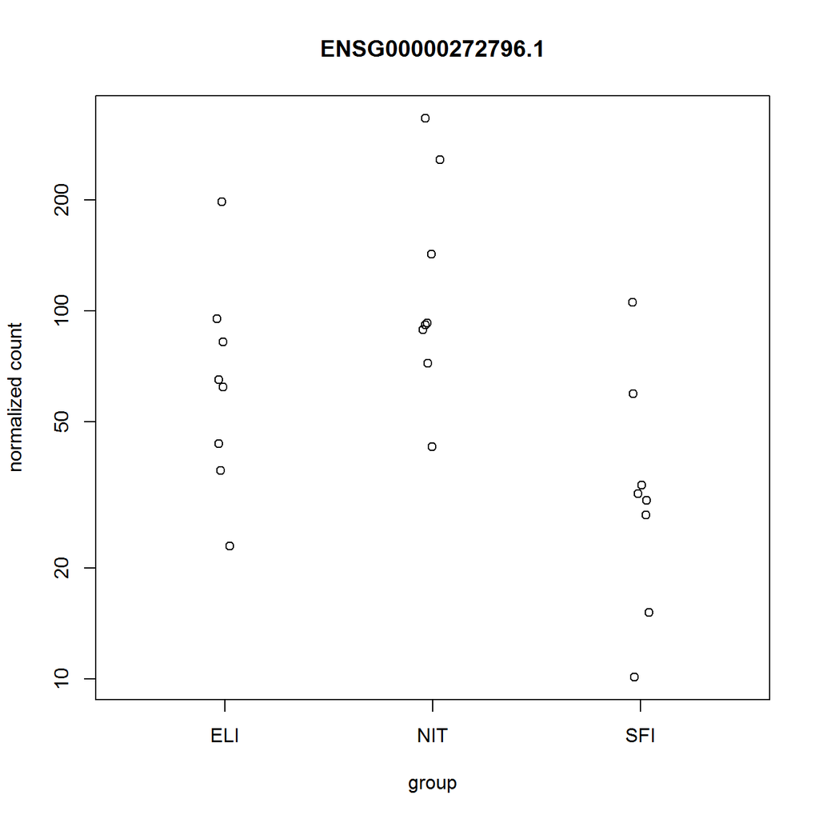

```r
> topGene <- rownames(res1)[which.min(res1$padj)]
> plotCounts(dds, gene = topGene, intgroup=c("Group"))
```

Hi hauria altres possibilitats de gràfics per visualitzar la diferenciació, però amb els resultats inicials ja es veu que hi ha molts poc gens expressats diferentment. Això fa que les altres tipus de gràfiques no siguin explicatives, per aquest motiu no s’han inclòs en l’anàlisis.

Per a més informació si es treballa amb altres dades, es pot consultar: http://master.bioconductor.org/packages/release/workflows/vignettes/rnaseqGene/inst/doc/rnaseqGene.html#sample-distances

### 3.3.5 Anotació dels resultats

Les taules resultants contenen els IDs dels gens segons Ensembles, però es pot tenir més informació sobre cada gen que pot ser més informativa per interpretar els resultats. Així doncs, resulta interessant afegir aquesta inforamció explicativa (anotacions) a partir de grans bases de dades sobre gens.

El paquet de **AnnotationDbi** de Bioconductor permet realitzar-ho, juntament amb la llibreria de gens sobre Homo sapiens **org.Hs.eg.db**. Concretament la funció `MapIds()` permet afegir informació. S’afegiran dues noves columnes: “SYMBOL” i “ENTREZID”. Per a fer-ho, aquesta funció permet realitzar un join entre es dues taules: la taula dels resultas i la base de dades general. Es defineix el camp clau entre les dues taules: “ENSEMBLE” i el nom de les columnes que s’afegiran: SYMBOL i ENTREZID. Cal indicar en la taula dels resultats com es diu el camp clau.

NOTA: en l’exemple presentat, el camp clau de la taula de resultats és el nom de les files: `row.names(resX)`; però resulta que al final del codi Ensemble té uns caràcter de més. Perquè puguin coïncidir exacatament amb la informaicó clau de la base de dades de *Homo sapiens* cal treure aquests caràcters de més. Concretament cal eliminar un “.” i el número que hi ha després del punt. Aquest procés es realitza alhora de definir el paràmetre “key=”:

```r
> library("AnnotationDbi")
> library("org.Hs.eg.db")
> columns(org.Hs.eg.db)
```

```
 [1] "ACCNUM"       "ALIAS"        "ENSEMBL"      "ENSEMBLPROT"  "ENSEMBLTRANS"
 [6] "ENTREZID"     "ENZYME"       "EVIDENCE"     "EVIDENCEALL"  "GENENAME"
[11] "GO"           "GOALL"        "IPI"          "MAP"          "OMIM"
[16] "ONTOLOGY"     "ONTOLOGYALL"  "PATH"         "PFAM"         "PMID"
[21] "PROSITE"      "REFSEQ"       "SYMBOL"       "UCSCKG"       "UNIGENE"
[26] "UNIPROT"
```

```r
> # per afegir el camp SYMBOL
> res1$symbol <- mapIds(org.Hs.eg.db,
+                      keys=gsub("\\..*", "", row.names(res1), fixed = FALSE), #amb gsub() eliminem el ".n"
+                      column="SYMBOL",
+                      keytype="ENSEMBL",
+                      multiVals="first")
>
> # per afegir el camp ENTREZID
> res1$entrez <- mapIds(org.Hs.eg.db,
+                      keys=gsub("\\..*", "", row.names(res1), fixed = FALSE),
+                      column="ENTREZID",
+                      keytype="ENSEMBL",
+                      multiVals="first")
>
> # veiem el resultat de les funcions d'afegir aquestes anotacions ordenat pel p-value:
> resOrdered1 <- res1[order(res1$pvalue),]
> head(resOrdered1)
```

```
log2 fold change (MLE): Group SFI vs NIT
Wald test p-value: Group SFI vs NIT
DataFrame with 6 rows and 8 columns
                           baseMean   log2FoldChange             lfcSE
                          <numeric>        <numeric>         <numeric>
ENSG00000163464.7  59.8366812612451 3.07483085853869 0.728686358273818
ENSG00000144278.10 13.7591297951613 2.30954559269801  0.55868630258581
ENSG00000166592.7   978.73252401272 1.31455977034994 0.319031569614357
ENSG00000269501.1  16.2235069407705 1.72898432485756 0.421972761742723
ENSG00000100427.11 17.5342247857503 1.74687390990636 0.431166576545444
ENSG00000188000.2  26.6723497243099 -3.7874014985478 0.936780184695035
                                stat               pvalue              padj
                           <numeric>            <numeric>         <numeric>
ENSG00000163464.7   4.21969043831512 2.44637998941988e-05 0.326228680493166
ENSG00000144278.10  4.13388619339434 3.56680146902481e-05 0.326228680493166
ENSG00000166592.7   4.12046924365188  3.7810154065385e-05 0.326228680493166
ENSG00000269501.1   4.09738372144438 4.17845940401759e-05 0.326228680493166
ENSG00000100427.11  4.05150585628068 5.08890521683785e-05 0.326228680493166
ENSG00000188000.2  -4.04299915863482 5.27718100904315e-05 0.326228680493166
                        symbol      entrez
                   <character> <character>
ENSG00000163464.7        CXCR1        3577
ENSG00000144278.10     GALNT13      114805
ENSG00000166592.7         RRAD        6236
ENSG00000269501.1           NA          NA
ENSG00000100427.11        MLC1       23209
ENSG00000188000.2        OR7D2      162998
```

Aquest procés es repeteix per a les altres dues taules de resultats.

Els resultats amb les anotacions es poden exportar a taules csv o fer uns reports en html:

```r
> resOrderedDF1 <- as.data.frame(resOrdered1)
> # com a csv:
> write.csv(resOrderedDF1, file = "res1.csv")
>
> #amb una eina de reporting en format html:
> library(ReportingTools)
> htmlRep1 <- HTMLReport(shortName="report1", title="My report",
+                       reportDirectory=".")
> publish(resOrderedDF1, htmlRep1)
> url <- finish(htmlRep1)
> #browseURL(url) # per obrir el report final
```

El procés d’exportació s’ha realitzat només com a exemple, només s’ha exportat la resposta de la comparació 1, es pot fer per a la resta canviant els noms correponents.

### 3.3.6 Cerca de patrons d’expressió i agrupació de les mostres (comparació entre les diferents comparacions)

Els gràfics tipus MAplots s’observen els canvis d’expressió entre parelles de mostres

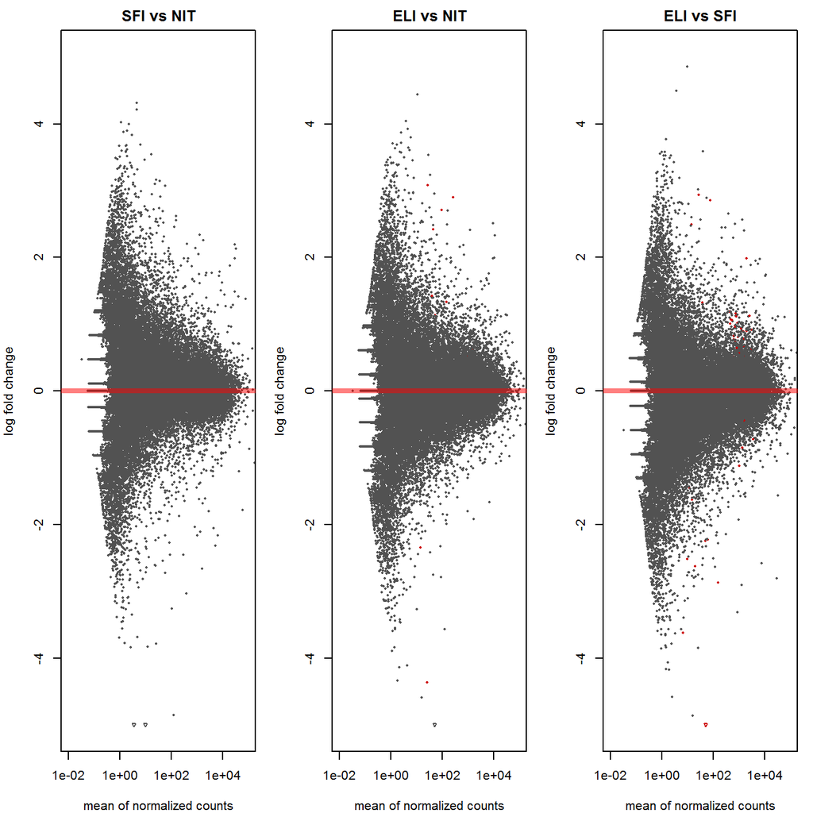

```r
> library(apeglm)
>
>
> par(mfrow=c(1,3), mar=c(4,4,2,1))
> ylim <- c(-5,5)
> xlim <- c(1e-2,1e5)
> plotMA(res1, xlim=xlim, ylim=ylim, main="SFI vs NIT")
> plotMA(res2, xlim=xlim, ylim=ylim, main="ELI vs NIT")
> plotMA(res3, xlim=xlim, ylim=ylim, main="ELI vs SFI")
```

O bé també es pot realitzar un anàlisis cluster en un HeatMap, sel·leccionant però els gens amb més variança entre mostres. Alhora si només ens fixem en quant es desvia cada gen d’una mostra específica de la mitjana entre mostres.

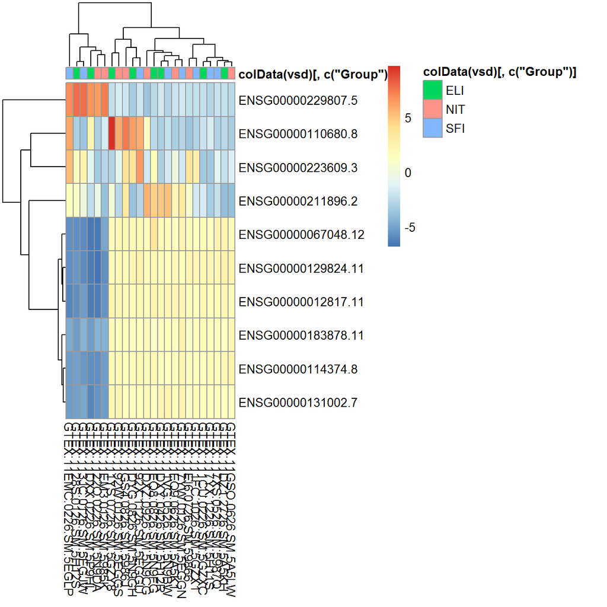

```r
> library("genefilter")
> #seleccionem els 10 gens
> topVarGenes <- head(order(rowVars(assay(vsd)), decreasing = TRUE), 10)
>
> mat  <- assay(vsd)[ topVarGenes, ]
> mat  <- mat - rowMeans(mat)
> anno <- as.data.frame(colData(vsd)[, c("Group")])
> rownames(anno) <- colnames(vsd)
> pheatmap(mat, annotation_col = anno)
```

El heatMap resultant però no mostra clarament diferències o similituds entre grups.